# 2 Multivariate approach: `cdn_way`

Based on Dollinger’s 2023 survey on CanE lg. attitudes

Authors

Affiliations

Lars Hinrichs

The University of Texas at Austin

Stefan Dollinger

University of British Columbia

## 1 The important questions

### 1.1 Dependent variables (DV)

According to Dollinger:

> Wichtig neben der **“way of speaking”** und **“distinct English”** question ist mir die **“Have your heard of the term Standard Canadian English?”** [Frage]

These three correspond to the column labels

- `cdn_way`,
- `distinct`, and
- `st_heard`.

### 1.2 Independent variables (IV)

According to Dollinger:

- `region`,
- `education`,
- `age`, and
- `gender`.

### 1.3 Method

Something on the more pedestrian side to begin with: a regression with the different values of the DV as outcome.

#### 1.3.1 Ordinal logistic regression using only one variable as outcome

Let’s start with the first of the DVs, `cdn_way`. Here are our responses:

```
# A tibble: 5 × 2
  cdn_way            n
  <chr>          <int>
1 definitely not    49
2 definitely yes   763
3 probably not     266
4 probably yes    1614
5 <NA>             274
```

To preprocess the data, we will

- eliminate NA cases and
- filter out non-Canadian respondents.

Because the `cdn_way` variable has levels that are *ordered* we will convert it into type `int` and sort the values properly.

```
# A tibble: 4 × 2
  cdn_way_num     n
        <dbl> <int>
1           1    37
2           2   194
3           3  1211
4           4   603
```

Ensure that the DV is an ordinal factor and other important variables are factors as well.

### 1.4 Model fitting

Fit the ordinal logistic regression model. Displaying only `head()` of the model output.

Ordinal Logistic Regression Summary

Model predicting cdn_way_num

| Predictor | Estimate (log-odds) | Odds Ratio | CI Lower | CI Upper | *p*-value | Significance |
| --- | --- | --- | --- | --- | --- | --- |
| age | 0.002 | 1.002 | −0.005 | 0.009 | 0.551 |  |
| gendermale | −0.126 | 0.882 | −0.306 | 0.054 | 0.170 |  |
| genderother | −0.085 | 0.919 | −0.517 | 0.343 | 0.698 |  |
| regionbc | −0.322 | 0.725 | −0.594 | −0.050 | 0.020 | * |
| regionmb | −0.084 | 0.919 | −0.380 | 0.211 | 0.576 |  |
| regionnb | −0.433 | 0.649 | −1.112 | 0.240 | 0.210 |  |
| regionnl | −0.580 | 0.560 | −1.306 | 0.138 | 0.116 |  |
| regionns | −0.541 | 0.582 | −1.198 | 0.110 | 0.105 |  |
| regionnt | −0.623 | 0.536 | −2.417 | 1.170 | 0.497 |  |
| regionon | 0.102 | 1.107 | −0.153 | 0.357 | 0.434 |  |
| regionpei | −0.019 | 0.981 | −0.671 | 0.624 | 0.954 |  |
| regionsk | −0.001 | 0.999 | −0.299 | 0.296 | 0.994 |  |
| regionyt | −0.695 | 0.499 | −2.295 | 0.916 | 0.400 |  |
| edu_compgraduate degree | 1.571 | 4.812 | 0.747 | 2.381 | 0.000 | *** |
| edu_comphigh school | 1.345 | 3.836 | 0.542 | 2.131 | 0.001 | *** |
| edu_compother | 1.470 | 4.349 | 0.633 | 2.293 | 0.001 | *** |
| edu_comppostgraduate degree | 1.499 | 4.476 | 0.650 | 2.333 | 0.000 | *** |
| edu_compundergraduate degree | 1.272 | 3.568 | 0.465 | 2.063 | 0.002 | ** |

*Note:* Odds ratios are exponentiated coefficients. Significance levels: *** *p* < .001, ** *p* < .01, * *p* < .05, **.** *p* < .1

### 1.5 Model term viz

Visualize the model terms. One approach is to plot each model term individually, like so for `gender`:

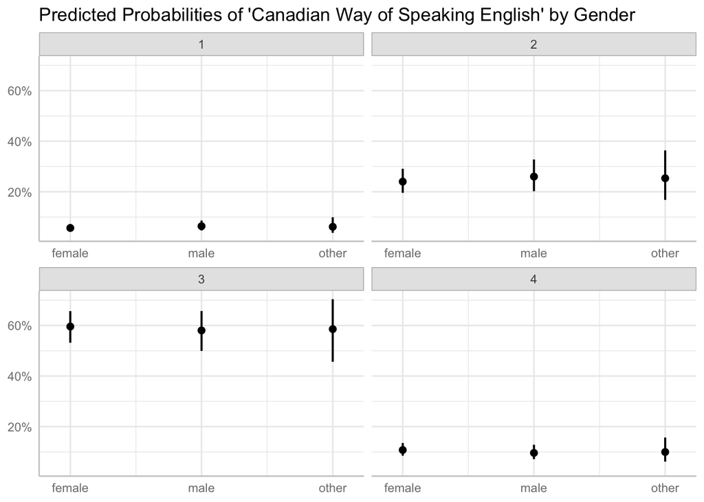

It actually looks like `gender` is a pretty boring predictor!

But this is not too useful, since we want to compare predictors. So now we try to plot all the model terms.

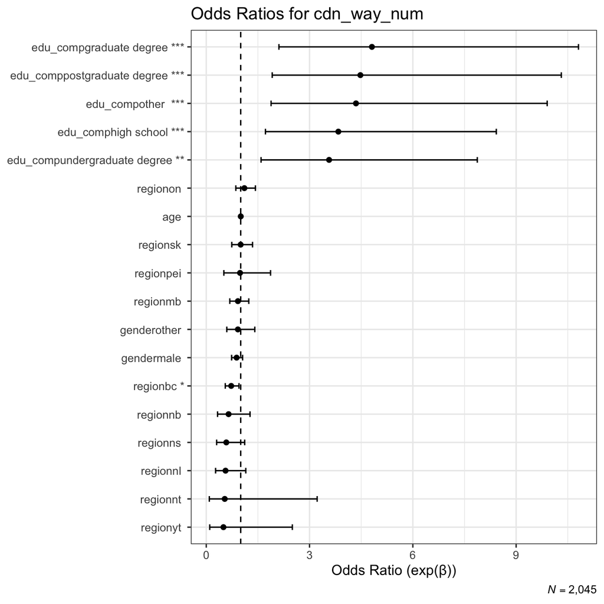

**Application values**  
For each predictor, one of the levels is not visualized. That’s the application value. So for gender, `female` is not shown. This means that the odds ratio for `female` is right on the dotted line (the model intercept), the other two values in the `gender` factor (`male` and `other`) are shown to the extent that they increase or decrease the chance of a higher rating in the response variable.  
**Which level of a factor is the application value?**  
It’s the one that’s first in the alphabet (cf. *female > male > other*).

In the spirit of a minimal adequate model, it would be best to drop the terms `gender` and `age` from the model entirely, since their predictions are weak and statistically insignificant.